# Lecture 2 Differential Expression Analysis (DEA)

Dennis Hazelett  
3/25/2021

### RNA-seq: The Goal

RNA-seq is a tool of systems biology

> Systems biology is an approach in biomedical research to understanding the larger picture—be it at the level of the organism, tissue, or cell—by putting its pieces together. It’s in stark contrast to decades of reductionist biology, which involves taking the pieces apart.

–Christophe Wanjek ([NIH website](https://irp.nih.gov/catalyst/v19i6/systems-biology-as-defined-by-nih))

- avoid drawing strong conclusions from individual genes
- support inference drawn from other experiments
- look at groups or clusters of related genes
- same laws of statistics, physics and chemistry apply

### RNA-seq: Workflows

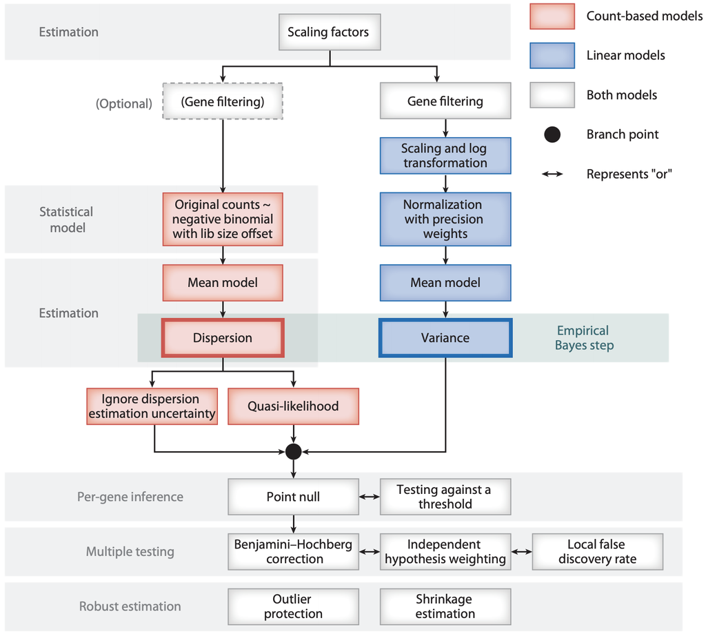

### A Word About Normalization

Normalization has two purposes:

- visualization
- fit data to a statistical model

### A Word About Normalization

Normalization has two purposes:

- visualization
- fit data to a statistical model

There are two approaches to RNA-seq expression analysis:

- fit data to a model
- fit a model to data

### A Word About Normalization

Normalization has two purposes:

- visualization
- fit data to a statistical model

There are two approaches to RNA-seq expression analysis:

- fit data to a model <– normal dist
- fit a model to data

### A Word About Normalization

Normalization has two purposes:

- visualization
- fit data to a statistical model

There are two approaches to RNA-seq expression analysis:

- fit data to a model <– normal dist <– **normalization**
- fit a model to data

### Types of normalization

- Counts per million (CPM)
- Scale, median and mean
- Trimmed mean of M-values (TMM/edgeR)
- Transcripts per million (TPM - Salmon)

### A Word About Distributions

We discussed two common workflows: DESeq2 and limma/voom

- **limma/voom**: log transform of exponential data to fit normal dist

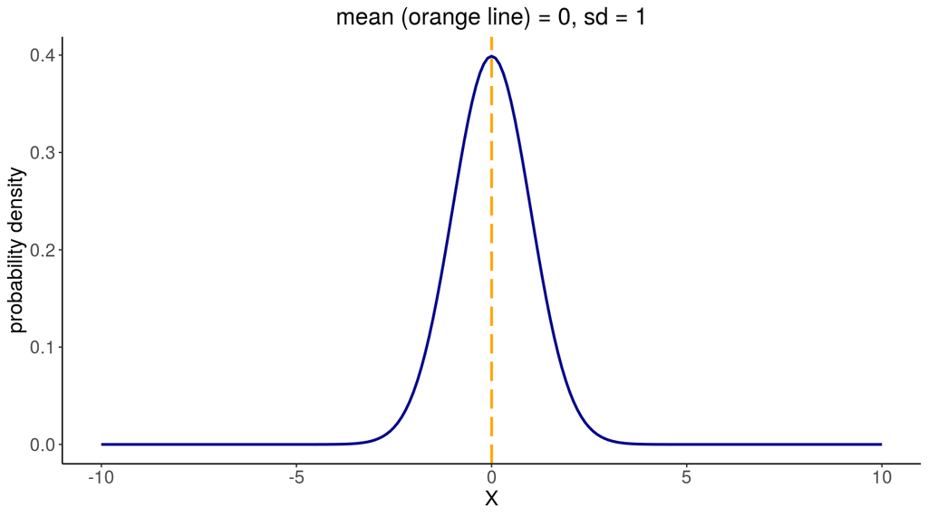

### A Word About Distributions

We discussed two common workflows: DESeq2 and limma/voom

- **Deseq2** (and *edgeR*): estimation of parameters from raw counts fit to NB dist

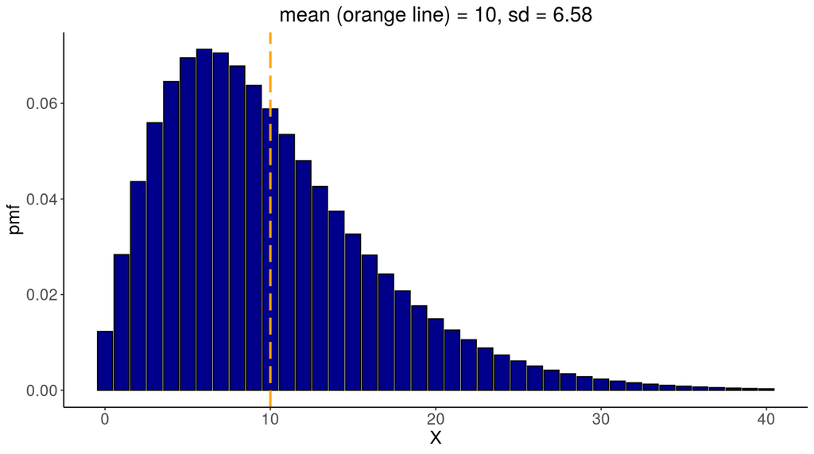

### A Word About Distributions

- Most data, in a *controlled experimental setting*, fit some distribution, often the normal dist.

### A Word About Distributions

- Most data, in a *controlled experimental setting*, fit some distribution, often the normal dist.
- However, many biological, ecological, epidemiological data, fit other distributions. [Explore these in the distribution zoo](https://ben18785.shinyapps.io/distribution-zoo/)

### A Word About Distributions

- Most data, in a *controlled experimental setting*, fit some distribution, often the normal dist.
- However, many biological, ecological, epidemiological data, fit other distributions. [Explore these in the distribution zoo](https://ben18785.shinyapps.io/distribution-zoo/)
- It is important to understand the distribution underlying the experiment, as the parameters can be related to the **data-generating process**.

### A Word About Distributions

- Most data, in a *controlled experimental setting*, fit some distribution, often the normal dist.
- However, many biological, ecological, epidemiological data, fit other distributions. [Explore these in the distribution zoo](https://ben18785.shinyapps.io/distribution-zoo/)
- It is important to understand the distribution underlying the experiment, as the parameters can be related to the **data-generating process**.
- The underlying assumption in experiments comparing treatment *vs.* control is that the distributions are the same, and the observed distribution parameters reflect systematic biases (experimental error)

### A Word About Distributions

- Most data, in a *controlled experimental setting*, fit some distribution, often the normal dist.
- However, many biological, ecological, epidemiological data, fit other distributions. [Explore these in the distribution zoo](https://ben18785.shinyapps.io/distribution-zoo/)
- It is important to understand the distribution underlying the experiment, as the parameters can be related to the **data-generating process**.
- The underlying assumption in experiments comparing treatment *vs.* control is that the distributions are the same, and the observed distribution parameters reflect systematic biases (experimental error)
- *Some DEA violate these assumptions*, and you should be aware of this when choosing an analysis strategy and interpreting the results.

### GENAVi

Steps:

- visualize
- choose a model
- differential analysis
- PCA (week 2)